# evgmrf

2026-02-23

# An opening generalized extreme value distribution example

We’ll start with an example fitting the generalized extreme value (GEV) distribution to a annual maxima for locations represented on a grid, where we use a Gaussian Markov random field (GMRF) to capture variation in the GEV distribution’s parameters over the grid. We’ll later look at other distributions, some GMRF properties, and other GRMF specifications.

## The GEV distribution

- Let $Y_{ijt}$ denote the annual maximum in year $t$ for grid row $i$ and column $j$
- We assume
  $$Y_{ijt} \sim GEV(\mu_{ij}, \psi_{ij}, \xi_{ij})$$
  where GEV distribution has cumulative distribution function (CDF)
  $$F_\text{GEV}(y; \mu, \psi, \xi) = \exp\left\{-\left[1 +
  \xi\left(\dfrac{y - \mu}{\psi}\right)\right]^{-1/\xi}\right\},$$
  which is defined for $\{y : 1 + \xi (y - \mu) / \psi > 0\}$ with $(\mu, \psi, \xi) \in \mathbb{R} \times \mathbb{R}^+ \times \mathbb{R}/\{0\}$. The limit $\xi \to 0$ is used for the $\xi = 0$ case, which corresponds to the Gumbel CDF, $\exp(-\exp\{-[(y - \mu)/\psi]\})$. For all models this limit is invoked in **evgmrf** if $|\xi| < 10^{-6}$.

## Some preliminaries

We’ll load a few packages, to make for slightly tidier code later.

```r
library(evgmrf)
library(MASS)
library(lattice)
```

## Some data

We’ll just generate some multivariate Gaussian data as an example. We’ll consider a $15 \times 10$ grid, with each cell having 50 years or data, from which we’ll extract annual maxima.

```r
nx <- 15
ny <- 10
nyrs <- 50
ndy <- 365
x <- 1:nx
y <- 1:ny
xy <- expand.grid(x = x, y = y)
D <- sqrt(outer(xy[, 1], xy[, 1], FUN = '-')^2 + outer(xy[, 2], xy[, 2], FUN = '-')^2)
C <- exp(-D^1.9999)
mu <- xy[,1] + xy[,2]
sigma <- 1 + xy[,2] / 20
z <- mvrnorm(nyrs * ndy, mu, sigma * C)
z2 <- array(t(z), c(nx, ny, ndy, nyrs))
z_max <- apply(z2, c(1, 2, 4), max)
```

Here’s a quick plot of the data, in terms of overall maxima at each location.

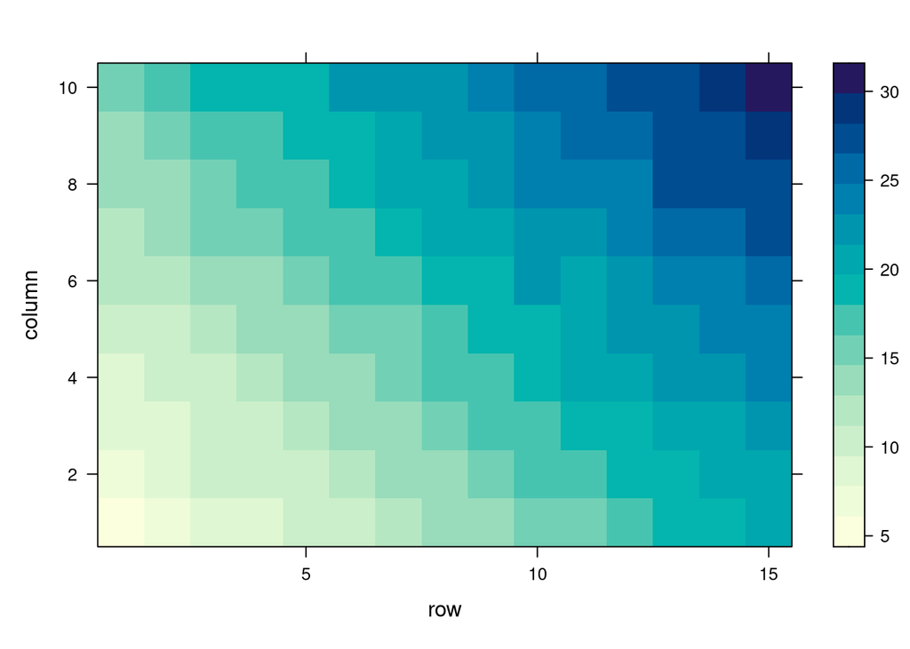

```r
levelplot(apply(z_max, 1:2, max), aspect = 'fill')
```

## Model fitting

We need to re-order our array of maxima so that we have $(t, i, j)$, where $t$ is the time index, $i$ is the row index, and $j$ is the column index.

```r
z_max2 <- aperm(z_max, c(3, 1, 2))
```

And this is enough to fit a GMRF model with `evgmrf` with its default arguments.

```r
m0 <- evgmrf(z_max2)
```

## Plots of parameter estimates

We can plot the model’s estimates

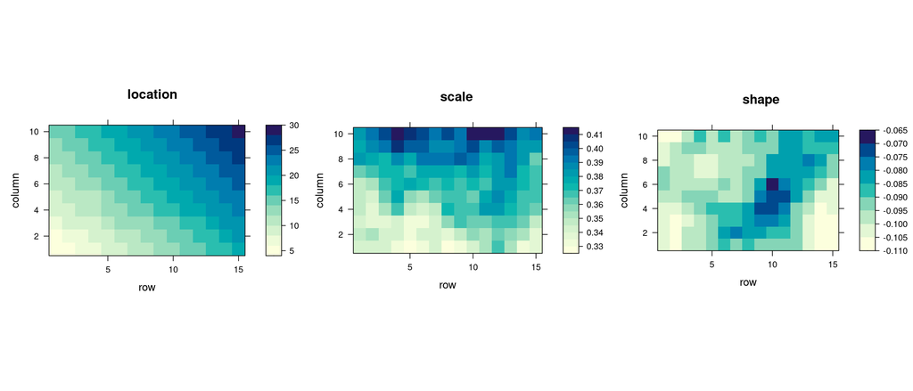

```r
plot(m0, type = 'response')
```

or we can estimate quantiles from the model

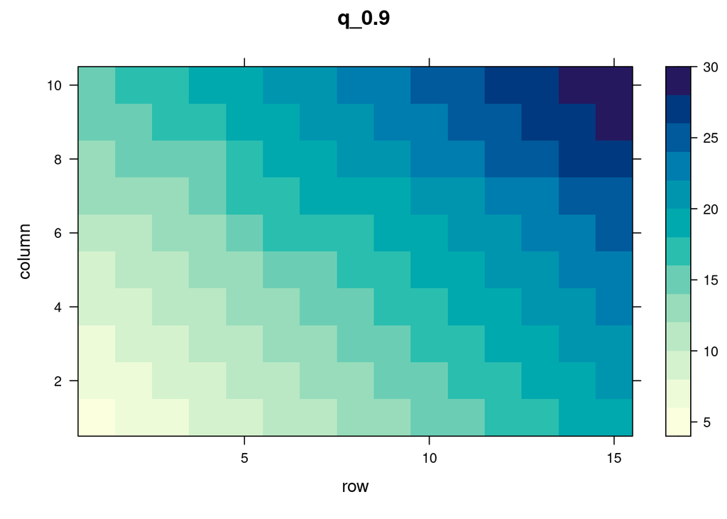

```r
plot(m0, prob = .9)
```

## Parameter estimate predictions with standard errors

We can extract the model’s estimates with standard errors

```r
pred0 <- predict(m0, se.fit = TRUE, progress = FALSE)
lapply(pred0, function(x) lapply(x, function(y) y[1:2, 1:5]))
```

```
## $fitted
## $fitted$location
##          [,1]     [,2]     [,3]     [,4]      [,5]
## [1,] 4.859214 5.867542 6.997584 8.023628  9.021669
## [2,] 5.865564 6.903993 8.095597 9.046106 10.106284
##
## $fitted$logscale
##           [,1]      [,2]      [,3]      [,4]      [,5]
## [1,] -1.077107 -1.056928 -1.068976 -1.060197 -1.063178
## [2,] -1.069327 -1.040060 -1.081041 -1.082015 -1.072184
##
## $fitted$transshape
##           [,1]      [,2]      [,3]      [,4]      [,5]
## [1,] 0.3986156 0.4015538 0.3916906 0.4022158 0.4099447
## [2,] 0.3834932 0.3843365 0.3900917 0.3997862 0.4078486
##
##
## $se
## $se$location
##            [,1]       [,2]       [,3]       [,4]       [,5]
## [1,] 0.04970274 0.05074287 0.05032272 0.05077677 0.05047195
## [2,] 0.05046064 0.05266845 0.04965248 0.04947698 0.04999592
##
## $se$logscale
##            [,1]       [,2]       [,3]       [,4]       [,5]
## [1,] 0.06140194 0.05291207 0.05187618 0.05121382 0.05210344
## [2,] 0.05244227 0.04472034 0.04638837 0.04703683 0.04733572
##
## $se$transshape
##            [,1]       [,2]       [,3]       [,4]       [,5]
## [1,] 0.08691302 0.07502725 0.07441247 0.07213628 0.07230395
## [2,] 0.07587321 0.06638532 0.06549569 0.06519914 0.06456534
```

We can extract the model’s estimates with standard errors

```r
pred1 <- predict(m0, se.fit = TRUE, progress = FALSE, prob = .99)
lapply(pred1, function(x) lapply(x, function(y) y[1:2, 1:5]))
```

```
## $fitted
## $fitted$q_0.99
##          [,1]     [,2]     [,3]      [,4]     [,5]
## [1,] 6.108459 7.145118 8.250383  9.297679 10.29946
## [2,] 7.110110 8.186327 9.331861 10.290347 11.37059
##
##
## $se
## $se$q_0.99
##           [,1]      [,2]       [,3]       [,4]       [,5]
## [1,] 0.1153194 0.1027281 0.10389929 0.10169781 0.10357988
## [2,] 0.1059726 0.0948522 0.09475859 0.09563168 0.09713502
```

# Distributions in `evgmrf`

The following distributions can be estimated with `evgmrf(..., family = '...')`:

### Generalized extreme value distribution: `family = 'gev'`

The GEV distribution is appropriate for block maxima of sufficiently large blocks. Here years will be considered as blocks, to help intuition; henceforth we will refer to maxima. A random variable $Y$ that is GEV distributed has cumulative distribution function (CDF)
$$F_\text{GEV}(y; \mu, \psi, \xi) = \exp\left\{-\left[1 +
\xi\left(\dfrac{y - \mu}{\psi}\right)\right]^{-1/\xi}\right\},$$
which is defined for $\{y : 1 + \xi (y - \mu) / \psi > 0\}$ with $(\mu, \psi, \xi) \in \mathbb{R} \times \mathbb{R}^+ \times \mathbb{R}/\{0\}$. The limit $\xi \to 0$ is used for the $\xi = 0$ case, which corresponds to the Gumbel CDF, $\exp(-\exp\{-[(y - \mu)/\psi]\})$. For all models this limit is invoked in **evgmrf** if $|\xi| < 10^{-6}$.

### $r$-largest order statistics

The $r$-largest order statistics models capture the GEV as the special case of $r=1$; i.e., instead of modelling just block maxima, the $r$-largest values in a block are modelled. This uses the same parameterisation as the GEV, with a resulting joint pdf for $y^{(1)} \geq \ldots \geq y^{(r)}$ given by
$$f_r(y^{(1)}, \ldots, y^{(r)}; \mu, \psi, \xi) = \exp\left\{-\left[1 +
\xi\left(\dfrac{y^{(r)} - \mu}{\psi}\right)\right]^{-1/\xi}\right\}
\prod_{i = 1}^r \psi^{-1} \left[1 + \xi\left(\dfrac{y^{(i)} -
\mu}{\psi}\right)\right]^{-1/\xi - 1},$$
which is defined as above and for for $\{y^{(i)} : 1 + \xi (y^{(i)} - \mu) / \psi > 0\}$, for $i = 1, \ldots, r$.

For these model, we can take the earlier data, and extract the $r$-largest order statistics instead. Let’s take $r = 3$.

```r
r <- 3
z_r <- apply(z2, c(1, 2, 4), function(x) sort(x, decreasing = TRUE)[1:r])
z_r2 <- aperm(z_r, c(4, 1, 2, 3))
m_rlarge <- evgmrf(z_r2, family = 'rlarge')
```

When we plot the $r$-largest order statistics model’s estimates, we’re plotting the same values as for the GEV

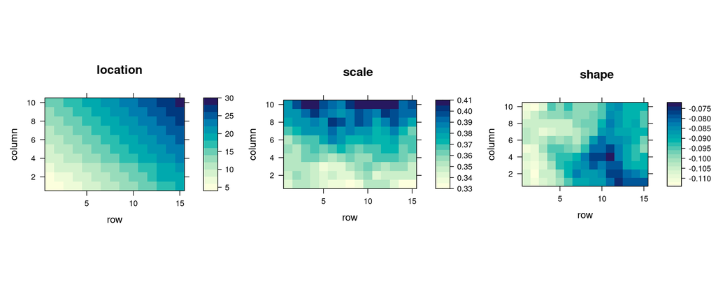

```r
plot(m_rlarge, type = 'response')
```

and see good agreement between the estimates.

### Generalized Pareto distribution

The GPD is used to model excesses of a high threshold $u$. For a random variable $Y$, it is a model for the conditional distribution $(Y-u) \mid (Y > u)$ with CDF
$$F_\text{GPD}^{(u)}(y; \psi_u, \xi) = 1 - \left[1 +
\xi\left(\dfrac{y}{\psi_u}\right)\right]^{-1/\xi},$$
which is defined for $\{y : y > 0 \text{ and } 1 + \xi y / \psi_u > 0\}$ with $(\psi_u, \xi) \in \mathbb{R}^+ \times \mathbb{R}/\{0\}$. The exponential CDF, $1 - \exp(-y/\psi_u)$, is used for the $\xi = 0$ case.

To demonstrate this model, we’ll take the earlier data and use a 98% empirical quantile estimate as the threshold, and set anything below the threshold as `NA`.

```r
z3 <- apply(z2, 1:2, c)
u <- round(apply(z2, 1:2, quantile, .98), 1)
z_exc <- z3 - rep(u, each = nyrs * ndy)
z_exc[z_exc <= 0] <- NA
```

Then, before fitting the model, we’ll re-order data across locations to put `NA`s at the end, and then drop any redundant dimensions using `tighten()`.

```r
z_gpd <- tighten(z_exc)
m_gpd <- evgmrf(z_gpd, family = 'gpd')
```

A plot of this model’s estimates is consistent with that seen earlier.

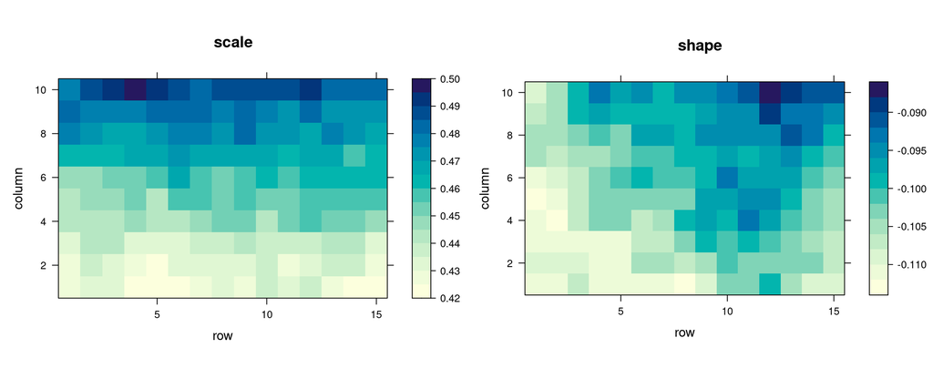

```r
plot(m_gpd, type = 'response')
```

### Poisson-GPD point process model

The Poisson-GPD point process model is considered as an extension of the GPD model with high threshold $u$ that allows estimation of GEV parameters. For random variables $\{Y_i\}_{i = 1, \ldots, n}$ and $y > u$ the Poisson-GPD model has intensity measure
$$\Lambda(A) = n_y (t_2 - t_1) \left[1 + \xi\left(\dfrac{y -
\mu}{\psi}\right)\right]^{-1/\xi},$$
where $A = [t_1, t_2] \times (y, \infty)$, $n_y$ is the time period under study and $t_i = (i - 0.5) / n$.

For this model, at each location we supply the threshold excesses, the threshold, and the time period we’re considering, which is `nyrs` from earlier. We’ve already constructed some of this data.

```r
z_pp <- z3
z_pp[is.na(z_exc)] <- NA

m_pp <- evgmrf(z_pp, family = 'pp', args = list(nper = nyrs, u = u))
```

Then we can plot the model, and should expect to see very similar parameter estimates to the GEV and $r$-largest order statistics models

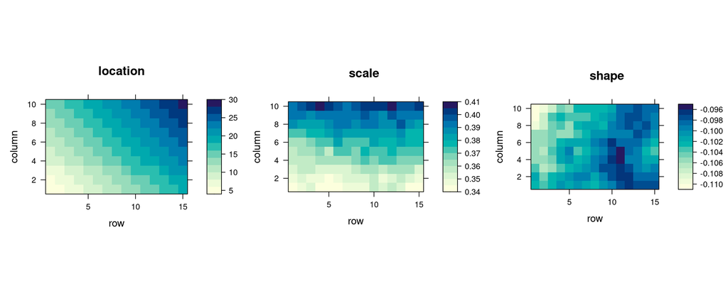

```r
plot(m_pp, type = 'response')
```

which we do.

### Asymmetric Laplace distribution

The ALD is not an EVD in the usual sense. It is useful in threshold-based extreme value analyses for allowing quantile estimation (Yu and Moyeed 2001). The GPD and Poisson-GPD models rely on a `high’ threshold. Coles (2001, chap. 4) discusses assessing its choice. High can be sometimes be intuitively defined through a high quantile, e.g., 0.9, 0.95 or 0.99. Quantile regression can be used to estimate such thresholds, especially covariate-dependent thresholds. The ALD has density function
$$f_{\text{ALD}, \tau}(y; u, \sigma, \tau) = \dfrac{\tau(1 -
\tau)}{\sigma} \exp\left\{-\rho_\tau\left(\dfrac{y -
u}{\sigma}\right)\right\},$$
where $\rho_\tau(y) = y(\tau - I\{y < 0\})$ is the check function, for indicator function $I\{\}$; see Koenker (2005) for an overview of quantile regression. The modified check function of Oh, Lee, and Nychka (2011) is used in **evgam** to ease inference.

For this model, we’ll again consider the 98th percentile. However, we’ll subset the data to the largest 10% at each location, and then estimate their 80th percentile. This is somewhat informative for occasions when we want to use quantile regression to estimate a high threshold, but want to significantly speed up its estimation.

The following picks out the highest 10% of the data

```r
z_ald <- apply(z3, 2:3, function(x) sort(x, decreasing = TRUE)[1:(.1 * nyrs * ndy)])
```

and then this `evgmrf` call uses quantile regression to estimate the 80th percentile.

```r
m_ald <- evgmrf(z_ald, family = 'ald', args = list(tau = .8))
```

We can plot the ALD’s location and (log) scale parameters

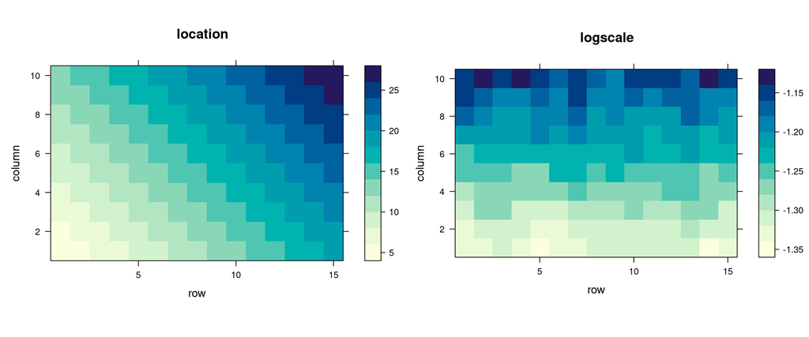

```r
plot(m_ald)
```

and we can also see that this approach gives good agreement to the earlier empirical 98th percentile estimates.

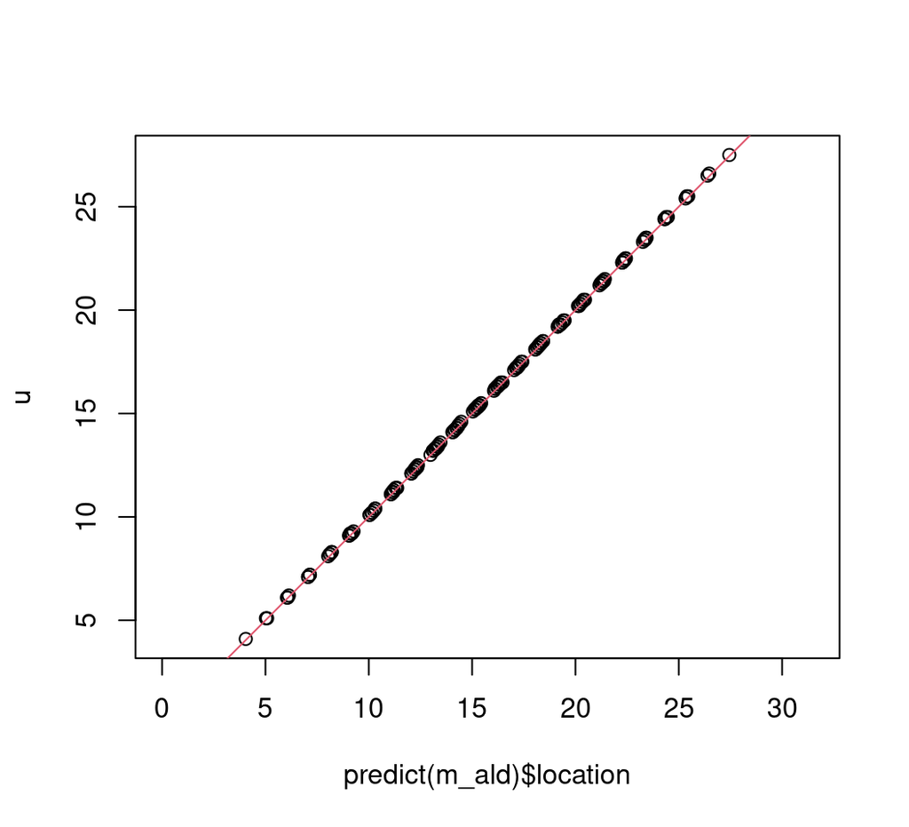

```r
plot(predict(m_ald)$location, u, asp = 1)
abline(0, 1, col = 2)
```

## References

Coles, Stuart G. 2001. *An Introduction to Statistical Modeling of Extreme Values*. Springer-Verlag. https://doi.org/10.1007/978-1-4471-3675-0.

Koenker, Roger. 2005. *Quantile Regression*. Cambridge University Press. https://doi.org/10.1017/cbo9780511754098.

Oh, Hee-Seok, Thomas C M Lee, and Douglas W Nychka. 2011. “Fast Nonparametric Quantile Regression with Arbitrary Smoothing Methods.” *Journal of Computational and Graphical Statistics* 20 (2): 510–26. https://doi.org/10.1198/jcgs.2010.10063.

Yu, Keming, and Rana A Moyeed. 2001. “Bayesian Quantile Regression.” *Statistics & Probability Letters* 54 (4): 437–47. https://doi.org/10.1016/s0167-7152(01)00124-9.